# GLM Assignment

Jake Barrett

9/14/2021

```r
library(ggplot2)
library(ggfortify)
library(dslabs)
library(datasets)
library(arm)
```

## Example 1: Poisson GLM

I found this dataset breaking down the number of gun homicides by state population in 2010 and wanted to analyze the relationship between a state’s population and its number of gun homicides (I know, depressing).

Because this dataset represent non-continuous count data, I began with the assumption that a Poisson model could be used to explain the data well.

**Data: Gun murders in the United States by state in 2010 (“murders” dataset from “dslabs”).**

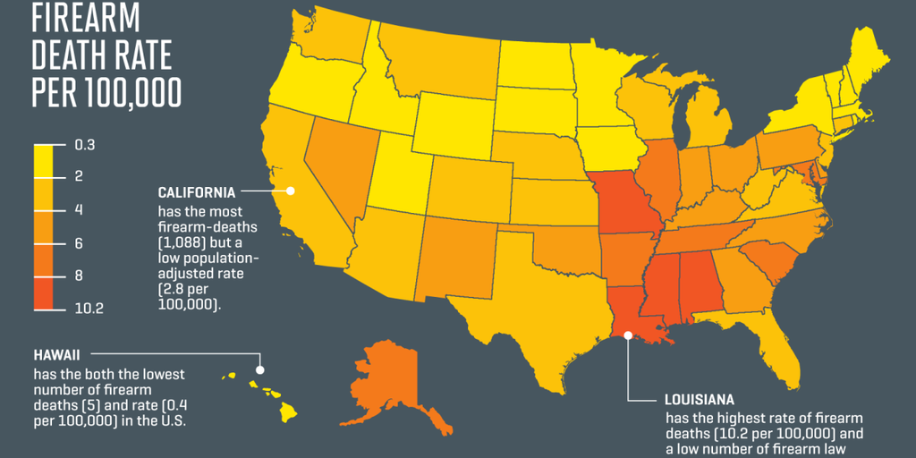

$~$

1.1 Model formation and visualization

$~$

To begin, I read in my data and formulated my model. I decided to use a GLM with a Poisson distribution as the data is essentially count data broken up by state.

Next, I visualized my data by fitting a Poisson distribution to it using “stat_smooth” with the ggplot() function.

$~$

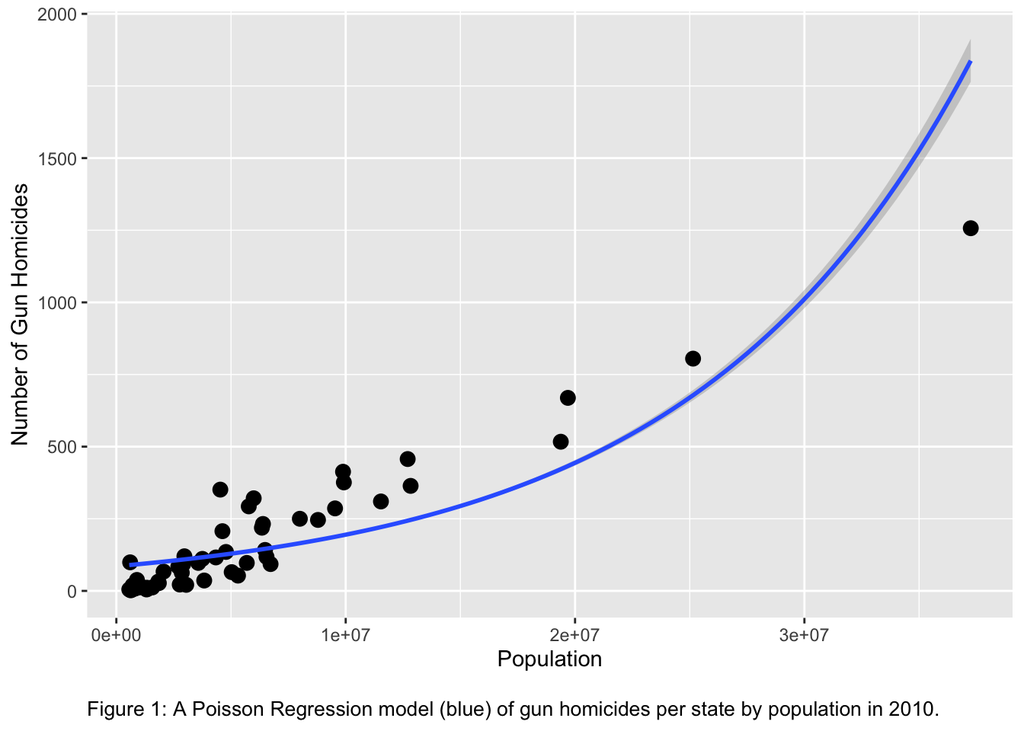

```r
guns <- murders

guns.glm <- glm(total ~ population, data = guns, family = poisson)

ggplot(guns, aes(population, total)) +
  geom_point(size=3) +
  #geom_smooth (method=lm, color="red") + #if you wanted to see the gaussian/identity fit
  stat_smooth(method = glm, method.args = list(family = poisson(link = "log"))) +
  xlab ("Population") +
  ylab ("Number of Gun Homicides") +
  labs(caption="Figure 1: A Poisson Regression model (blue) of gun homicides per state by population in 2010.") +
  theme(plot.caption=element_text(size=10, hjust=0, margin=margin(15,0,0,0)))
```

$~$

It’s not a great fit and there appears to me a lot of deviance from the model, but the model may be a better fit for many of the smaller states (lower on the model curve).

$~$

1.2 Poisson model diagnostic plots

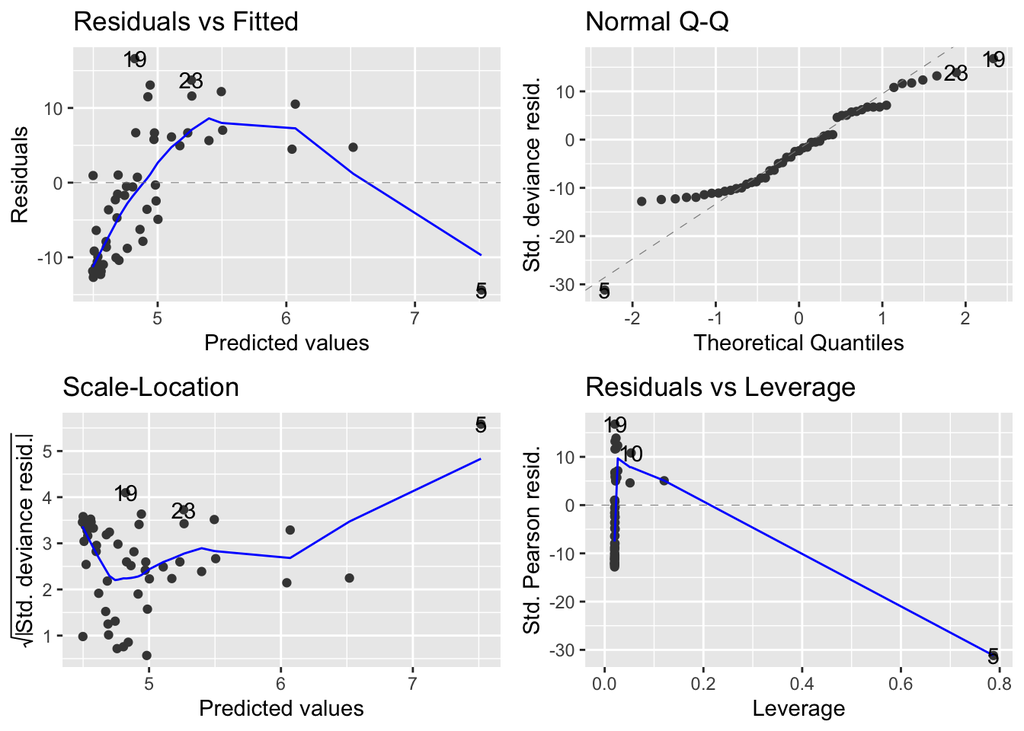

```r
autoplot(guns.glm)
```

$~$

**Residuals-fitted** –> *Pattern driven by several points on the right indicates an issue with the model?*

$~$

**Normal Q-Q** –> *Slight deviation at either end, but overall ‘OK’. Point 5 is perhaps slightly concerning, though.*

$~$

**Scale-location plot** –> *Slight positive relationship between the size of the residuals and the fitted values, driven by really one point, indicates that the Poisson might not be the best model.*

$~$

**Residuals-leverage** –> *Seems worrying.*

$~$

Overall, there are a couple of reasons to be concerned about the fit of our Poisson model to the data. For now, let’s look at the deviance table.

$~$

1.3 Deviance table

Next, I used the anova() function to get the deviance table.

```r
anova(guns.glm)
```

```
## Analysis of Deviance Table
##
## Model: poisson, link: log
##
## Response: total
##
## Terms added sequentially (first to last)
##
##
##            Df Deviance Resid. Df Resid. Dev
## NULL                          50      11596
## population  1   7813.5        49       3782
```

As you can see, there is quite a lot of unexplained deviance in this model fit. The deviance explained by population is 7814 units, the unaccounted-for deviance is 3782 units, and the total deviance from the model is 11596.

Next, let’s look at the summary table…

$~$

1.4 Summary table

```r
summary(guns.glm)
```

```
##
## Call:
## glm(formula = total ~ population, family = poisson, data = guns)
##
## Deviance Residuals:
##     Min       1Q   Median       3Q      Max
## -14.374   -9.533   -2.293    5.708   16.604
##
## Coefficients:
##              Estimate Std. Error z value Pr(>|z|)
## (Intercept) 4.449e+00  1.528e-02   291.1   <2e-16 ***
## population  8.234e-08  7.845e-10   105.0   <2e-16 ***
## ---
## Signif. codes:  0 '***' 0.001 '**' 0.01 '*' 0.05 '.' 0.1 ' ' 1
##
## (Dispersion parameter for poisson family taken to be 1)
##
##     Null deviance: 11596  on 50  degrees of freedom
## Residual deviance:  3782  on 49  degrees of freedom
## AIC: 4101.7
##
## Number of Fisher Scoring iterations: 5
```

The high z-value (105) indicates that the estimate for the effect of population on the number of gun homicides is significantly different from 0. However, the extremely high ratio of our residual deviance (3782) to the degrees of freedom (49) tells us that our model is overdispersed.

In order to try and account for some of the residual deviance I decided to formulate and view the summary table for a quasi-Poisson.

$~$

1.5 Quasi-Poisson formation and analysis

```r
guns.qpois <- glm(total ~ population, quasipoisson, data= guns)
summary(guns.qpois)
```

```
##
## Call:
## glm(formula = total ~ population, family = quasipoisson, data = guns)
##
## Deviance Residuals:
##     Min       1Q   Median       3Q      Max
## -14.374   -9.533   -2.293    5.708   16.604
##
## Coefficients:
##              Estimate Std. Error t value Pr(>|t|)
## (Intercept) 4.449e+00  1.286e-01   34.58   <2e-16 ***
## population  8.234e-08  6.604e-09   12.47   <2e-16 ***
## ---
## Signif. codes:  0 '***' 0.001 '**' 0.01 '*' 0.05 '.' 0.1 ' ' 1
##
## (Dispersion parameter for quasipoisson family taken to be 70.86689)
##
##     Null deviance: 11596  on 50  degrees of freedom
## Residual deviance:  3782  on 49  degrees of freedom
## AIC: NA
##
## Number of Fisher Scoring iterations: 5
```

The quasi-Poisson didn’t achieve any better of a ratio between the residual deviance and our degrees of freedom, but with a higher dispersion pattern we would expect it to take more of the overdispersion into account. Additionally, the highly significant and rounded nature of the p-values in the summary table doesn’t allow us to make comparisons there, either.

But what about a Gaussian GLM?

$~$

1.6 Gaussian model fit and visualization

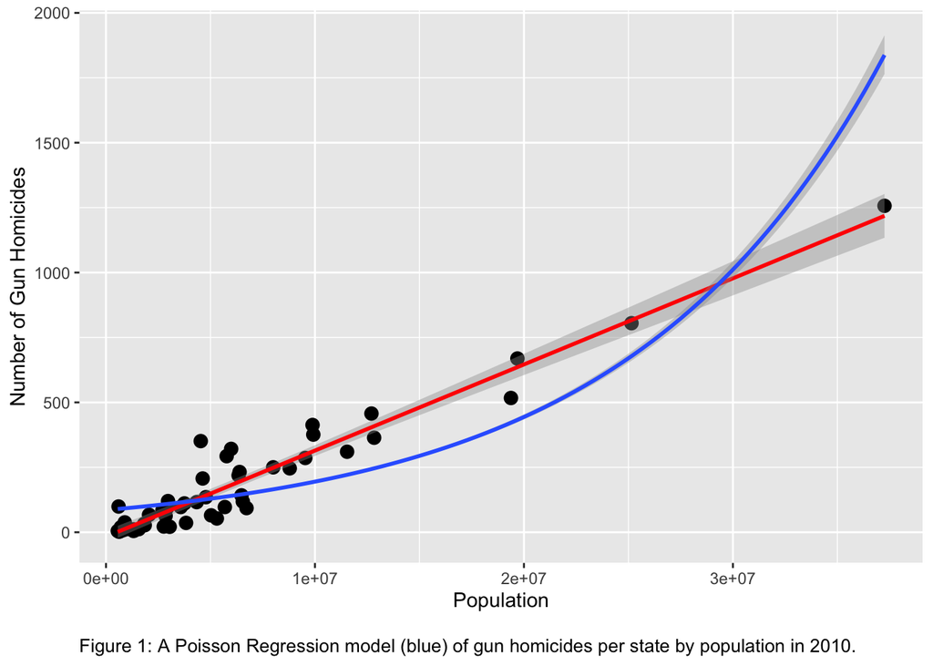

```r
guns.glm.gaussian <- glm(total~population, family=gaussian(link="identity"), data = guns)
ggplot(guns, aes(population, total)) +
  geom_point(size=3) +
  geom_smooth (method=lm, color="red") + #if you wanted to see the gaussian/identity fit
  stat_smooth(method = glm, method.args = list(family = poisson(link = "log"))) +
  xlab ("Population") +
  ylab ("Number of Gun Homicides") +
  labs(caption="Figure 1: A Poisson Regression model (blue) of gun homicides per state by population in 2010.") +
  theme(plot.caption=element_text(size=10, hjust=0, margin=margin(15,0,0,0)))
```

The Gaussian model LOOKS good, but let’s look at the summary table

$~$

1.7 Gaussian summary table

```r
summary(guns.glm.gaussian)
```

```
##
## Call:
## glm(formula = total ~ population, family = gaussian(link = "identity"),
##     data = guns)
##
## Deviance Residuals:
##      Min        1Q    Median        3Q       Max
## -112.889   -25.656    -3.687    25.505   217.780
##
## Coefficients:
##               Estimate Std. Error t value Pr(>|t|)
## (Intercept) -1.713e+01  1.198e+01   -1.43    0.159
## population   3.316e-05  1.315e-06   25.23   <2e-16 ***
## ---
## Signif. codes:  0 '***' 0.001 '**' 0.01 '*' 0.05 '.' 0.1 ' ' 1
##
## (Dispersion parameter for gaussian family taken to be 4066.942)
##
##     Null deviance: 2787778  on 50  degrees of freedom
## Residual deviance:  199280  on 49  degrees of freedom
## AIC: 572.53
##
## Number of Fisher Scoring iterations: 2
```

$~$

The Gaussian model has even MORE unexplained deviance from the model than our Poisson or quasi-Poisson. Therefore, I decided that the **quasi-Poisson** explains this data the best out of our considered models as it has less unexplained variance compared to the Gaussian and accounts for more overdispersion than our basic Poisson model.

$~$

1.8 Prediction for a state of 30,000,000.

```r
exp(4.449e+00 + 8.234e-08*3e7)
```

```
## [1] 1011.51
```

**For a state of 30,000,000 people, we would expect about 1,012 gun homicides (based on our model).**

$~$

## Example 2: Binomial GLM

I decided to analyze a “bird” dataset that I had used previously and that contains several binomial variates. The collectors of the dataset measured the presence or absence of a species of bird at many sampled locations and simultaneously measured several characteristics of the sample sites.

I was interested in using a binomial GLM to assess the relationship between the elevation at a sample site and the likelihood of finding this species.

$~$

2.1 Binomial formation and data visualization

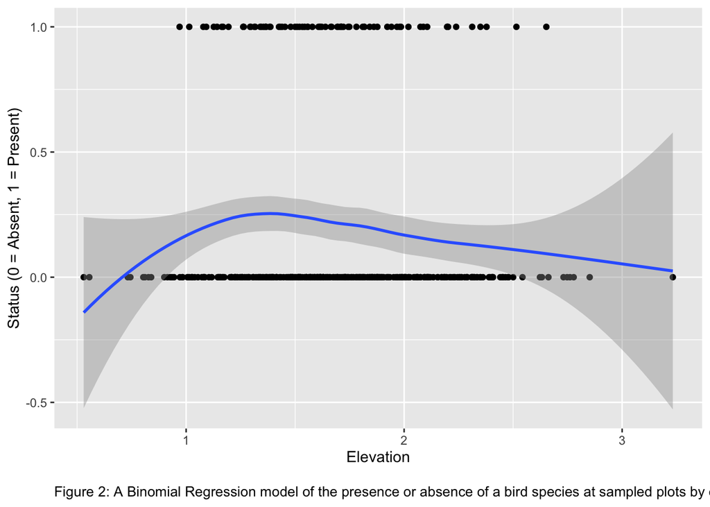

```r
birds <- read.csv("bird_data.csv")

birds.glm <- glm(Presence~Elevation, data=birds, binomial(link="logit"))

ggplot(birds, aes(Elevation, Presence)) +
  geom_point() +
  geom_smooth() +
  xlab ("Elevation") +
  ylab ("Status (0 = Absent, 1 = Present)") +
  labs(caption="Figure 2: A Binomial Regression model of the presence or absence of a bird species at sampled plots by elevation.") +
  theme(plot.caption=element_text(size=10, hjust=0, margin=margin(15,0,0,0)))
```

2.2 Binomial formation and data visualization

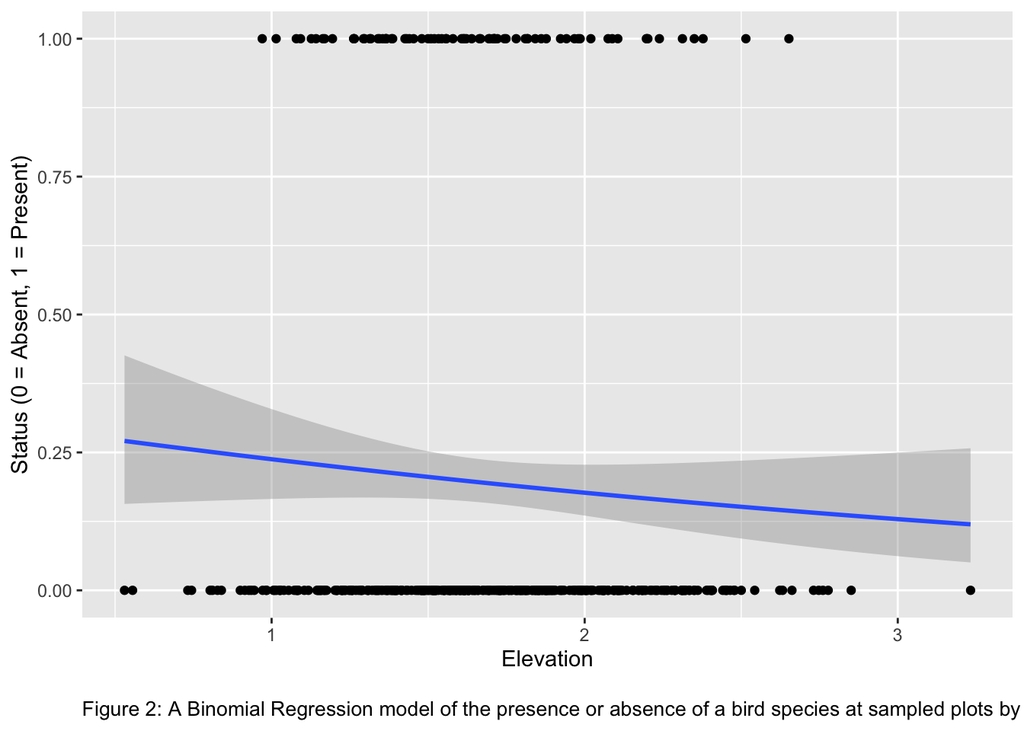

```r
ggplot(birds, aes(Elevation, Presence)) +
  geom_point() +
  geom_smooth(method="glm", method.args=list(family="binomial"(link="logit"))) +
  xlab ("Elevation") +
  ylab ("Status (0 = Absent, 1 = Present)") +
  labs(caption="Figure 2: A Binomial Regression model of the presence or absence of a bird species at sampled plots by elevation.") +
  theme(plot.caption=element_text(size=10, hjust=0, margin=margin(15,0,0,0)))
```

$~$

2.3 Diagnostic plots

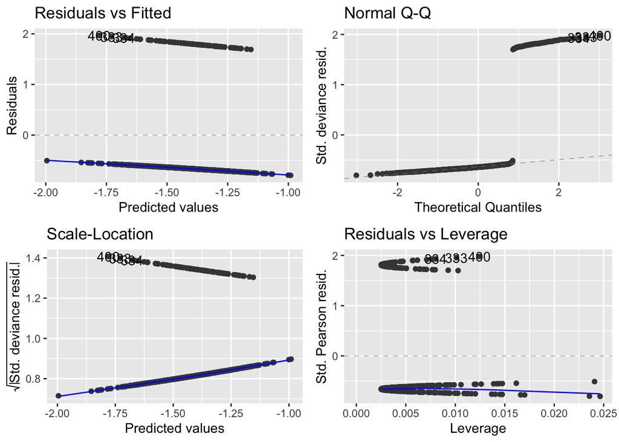

```r
autoplot(birds.glm)
```

As we would expect, not helpful due to the binary, restricted nature of binomial data.

Use binnedplot() to graphically assess the model for overdispersion!

$~$

2.4 Binnedplot

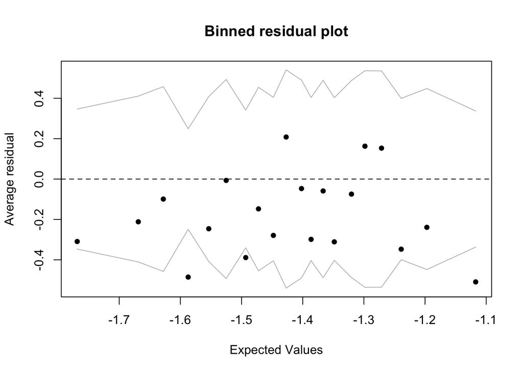

```r
x <- predict(birds.glm)
y <- resid(birds.glm)
binnedplot(x, y)
```

As can be seen in the resulting plot, nearly all of the residuals fall within +/- two standard errors.

$~$

2.5 Coefficients and confidence intervals

```r
coef(birds.glm)
```

```
## (Intercept)   Elevation
##  -0.7936501  -0.3718350
```

```r
confint(birds.glm)
```

```
##                  2.5 %    97.5 %
## (Intercept) -1.7856663 0.1837142
## Elevation   -0.9534059 0.1965166
```

Assuming significance, it appears that every unit increase in elevation means that this bird species is less likely to be found at that site.

$~$

2.6 Assessing significance

```r
confint(birds.glm)
```

```
##                  2.5 %    97.5 %
## (Intercept) -1.7856663 0.1837142
## Elevation   -0.9534059 0.1965166
```

```r
summary(birds.glm)
```

```
##
## Call:
## glm(formula = Presence ~ Elevation, family = binomial(link = "logit"),
##     data = birds)
##
## Deviance Residuals:
##     Min       1Q   Median       3Q      Max
## -0.7947  -0.6800  -0.6400  -0.5834   1.9676
##
## Coefficients:
##             Estimate Std. Error z value Pr(>|z|)
## (Intercept)  -0.7937     0.5012  -1.584    0.113
## Elevation    -0.3718     0.2926  -1.271    0.204
##
## (Dispersion parameter for binomial family taken to be 1)
##
##     Null deviance: 394.71  on 399  degrees of freedom
## Residual deviance: 393.08  on 398  degrees of freedom
## AIC: 397.08
##
## Number of Fisher Scoring iterations: 4
```

$~$

Our confidence intervals cotain 0 and we have non-significant p-values. **Therefore, there’s likely not a significant effect of elevation on the presence of this species.**

$~$

2.7 Back-calculating coefficients

```r
invlogit <- function(x) {1 / ( 1+exp(-x) ) }
invlogit(coef(birds.glm))
```

```
## (Intercept)   Elevation
##   0.3113855   0.4080977
```

*Not particularly important given our confidence intervals non-significant p-values.*

$~$